# Figure 2

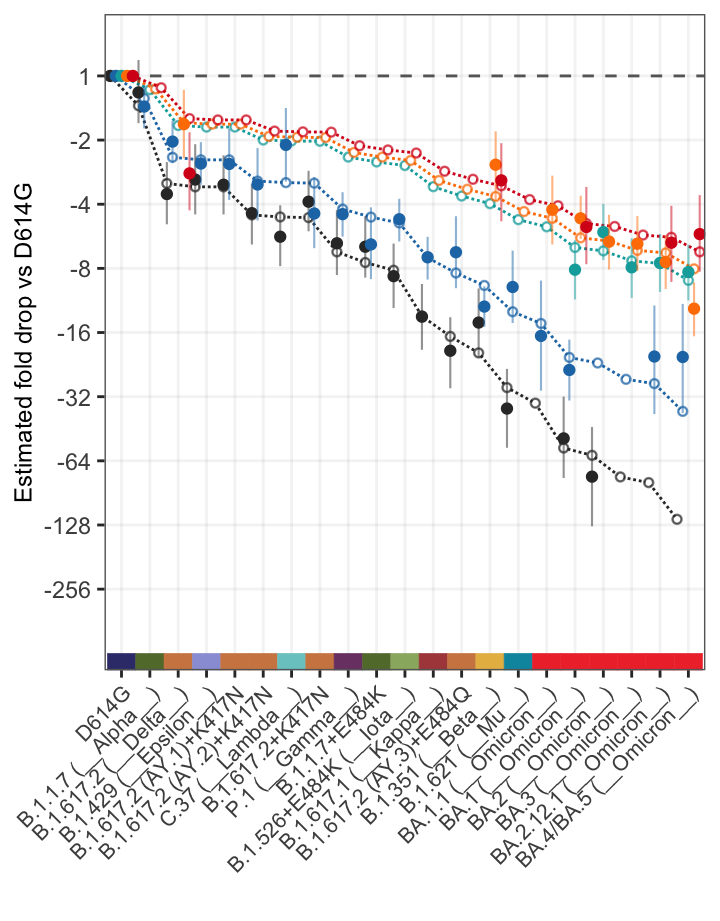

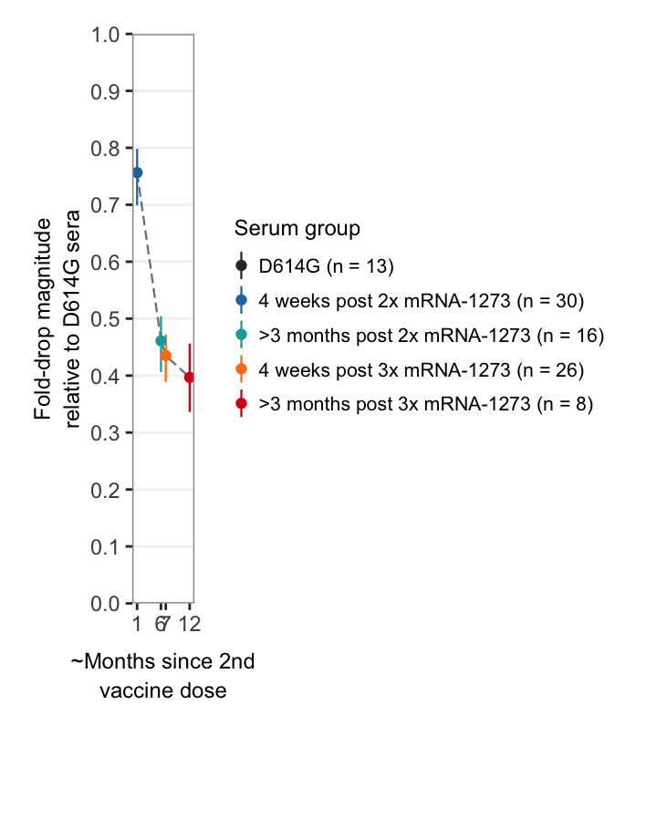

**Comparison of fold-drops to different variants in post D614G infection and post mRNA-1273 vaccination sera.** **A)** Comparison of different estimates of titer fold-drop responses against different variants. Solid points show the estimate for the mean fold drop compared to the titer for D614G, while lines represent the 95% highest density interval for this estimate. The points for D614G to the left of the plot represents the homologous virus against which fold-change for other strains was compared, and are therefore fixed at 1. Dotted lines and outline circles show estimates based on a model that assumes a shared overall pattern of fold-drops but estimates “slope” differences in the rate of reactivity drop-off seen in the 4 serum groups. To aid comparison, points and lines for each of the serum groups have some offset in the x-axis. **B)** Estimates of fold-drop magnitudes for each mRNA-1273 serum group, relative to the fold-drops seen in the D614G convalescent serum group. Lines show the 95% highest density interval for each of the estimates and position on the x axis is proportional to the number of months since 2nd vaccine dose, assuming an average of 6 months for sera in the 2x mRNA-1273 (>3 month) group. **C)** Antibody landscapes showing how estimates of the mean titer for each of the serum groups in panel A vary across antigenic space. **D)** Antibody landscapes as shown in C but fixed to have the same peak titer (2560) against the D614G variant in order to visualize differences in the slope of the titer drop-off based on a fixed magnitude of response.

### A.

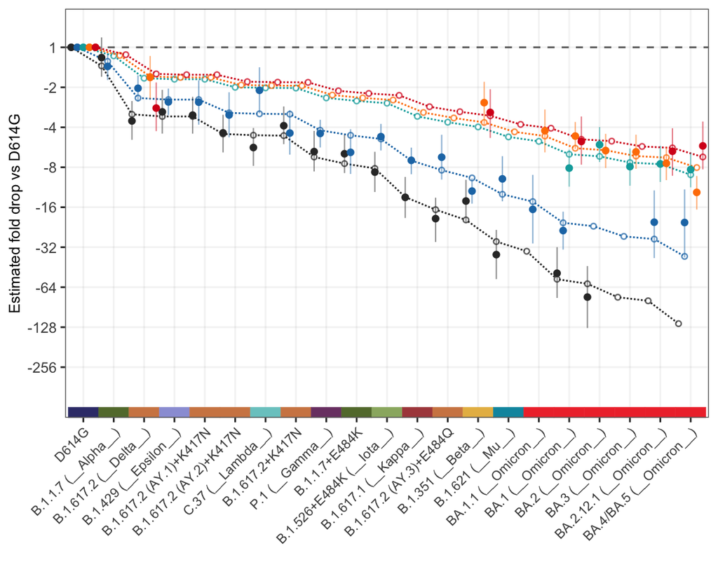

### B.

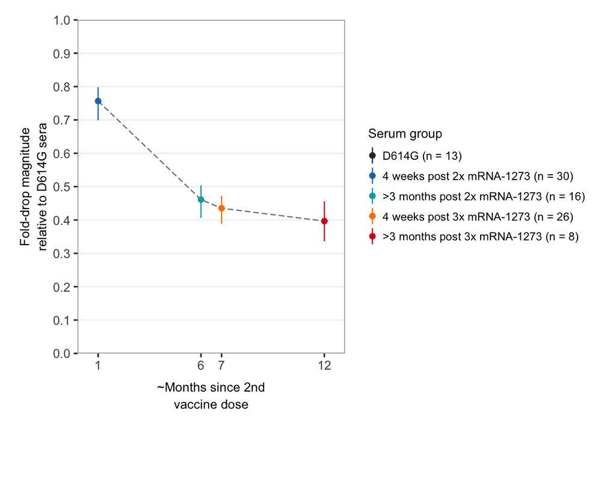

### C.

[interactive chart not shown]

### D.

[interactive chart not shown]